# Projekt 1 SAD

Karol Kita

2022-11-26

### **1) Wstęp**

Celem projektu jest dokonanie klasyfikacji oraz pogrupowania 30 wybranych telefonów komórkowych z użyciem metod porządkowania liniowego i analizy skupień. W projekcie posłużę się zmiennymi opisującymi parametry telefonów takimi jak: rozmiar wyświetlacza, waga telefonu, pojemność baterii, iość pamięci wbudowanej, rozdzielczość przedniego oraz tylnego aparatu, pamięcią RAM oraz ceną telefonu. W analizie zostaną użyte również oceny użytkowników serwisu mgsm.pl za poszczególny model telefonu.

### **2) Opis oraz wstępna analiza danych**

Wczytanie danych

```r
options(scipen = 1, digits = 3)
dane <- read.csv2("telefony.csv", sep = ";", header = TRUE)
row.names(dane) <- dane$Telefon
dane$Telefon <- NULL
dane$Wyswietlacz <- as.numeric(dane$Wyswietlacz)
dane$Ocena <- as.numeric(dane$Ocena)

library(knitr)
kable(dane)
```

|  | Wyswietlacz | Waga | Bateria | Pamiec | Ap_tyl | Ap_przod | RAM | Cena | Ocena |
| --- | --- | --- | --- | --- | --- | --- | --- | --- | --- |
| Samsung Galaxy S22 | 6.10 | 168 | 3700 | 128 | 50 | 10 | 8 | 3699 | 7.59 |
| iPhone 13 | 6.10 | 174 | 3300 | 256 | 12 | 12 | 4 | 4939 | 5.14 |
| Xioami 12 Pro | 6.73 | 205 | 4600 | 256 | 50 | 32 | 12 | 5200 | 6.76 |
| Oppo Find X5 Pro | 6.70 | 218 | 5000 | 256 | 50 | 32 | 12 | 5119 | 7.41 |
| iPhone 14 | 6.10 | 172 | 3300 | 512 | 12 | 12 | 6 | 7199 | 6.53 |
| Xioami 11T Pro | 6.67 | 204 | 5000 | 128 | 108 | 16 | 8 | 2899 | 7.18 |
| iPhone 12 mini | 5.40 | 133 | 3000 | 256 | 12 | 12 | 4 | 4099 | 8.08 |
| Oppo Reno 6 | 6.43 | 182 | 3000 | 128 | 64 | 32 | 8 | 2000 | 7.23 |
| Samsung Galaxy S21 Ultra | 6.80 | 227 | 5000 | 256 | 108 | 40 | 12 | 5999 | 7.36 |
| Nothing Phone 1 | 6.55 | 194 | 4500 | 256 | 50 | 16 | 12 | 2619 | 7.20 |
| OnePlus 9 Pro | 6.70 | 197 | 4500 | 128 | 50 | 12 | 8 | 3379 | 8.11 |
| Vivo V21 | 6.44 | 176 | 4000 | 128 | 64 | 44 | 8 | 1599 | 4.40 |
| Realme GT 2 | 6.70 | 199 | 5000 | 256 | 50 | 32 | 12 | 3799 | 7.23 |
| Xioami Poco F4 | 6.67 | 204 | 4500 | 128 | 64 | 20 | 6 | 2049 | 7.18 |
| Motorola Edge 20 Pro | 6.70 | 190 | 4500 | 256 | 108 | 32 | 12 | 3011 | 7.08 |
| Realme GT Master | 6.43 | 174 | 4300 | 128 | 64 | 32 | 6 | 1499 | 8.03 |
| Samsung Galaxy A52s | 6.50 | 189 | 4500 | 128 | 64 | 32 | 6 | 1999 | 7.75 |
| Samsung Galaxy Z Flip 3 | 6.70 | 183 | 3300 | 128 | 12 | 10 | 8 | 4799 | 8.89 |
| Oppo Reno 5z | 6.43 | 173 | 4300 | 128 | 48 | 16 | 8 | 1800 | 8.89 |
| Poco M4 Pro | 6.60 | 180 | 5000 | 64 | 50 | 16 | 4 | 1099 | 7.43 |
| Samsung Galaxy M23 | 6.60 | 198 | 5000 | 128 | 50 | 8 | 4 | 1299 | 6.43 |
| Motorola Edge 20 | 6.60 | 169 | 5000 | 128 | 50 | 16 | 4 | 1099 | 6.99 |
| Huawei Nova Y70 | 6.75 | 199 | 6000 | 128 | 48 | 8 | 4 | 849 | 6.11 |
| Realme 8 | 6.40 | 177 | 5000 | 64 | 64 | 16 | 4 | 899 | 7.71 |
| Vivo Y33 | 6.58 | 140 | 5000 | 128 | 50 | 16 | 8 | 919 | 5.00 |
| Xioami Redmi 9A | 6.53 | 196 | 5000 | 32 | 13 | 5 | 2 | 549 | 6.01 |
| Alcatel 1 | 5.00 | 134 | 2000 | 16 | 5 | 2 | 1 | 300 | 5.39 |
| Motorola Moto E20 | 6.50 | 185 | 4000 | 32 | 13 | 5 | 2 | 499 | 6.43 |
| Sony Xperia Pro-I | 6.50 | 211 | 4500 | 512 | 12 | 8 | 12 | 7499 | 7.48 |
| iPhone 13 Pro | 6.10 | 204 | 3100 | 512 | 12 | 12 | 6 | 7000 | 5.37 |

#### **Analiza danych**

Podstawowe statystki

```r
summary(dane)
```

```
##   Wyswietlacz        Waga        Bateria         Pamiec        Ap_tyl
##  Min.   :5.00   Min.   :133   Min.   :2000   Min.   : 16   Min.   :  5.0
##  1st Qu.:6.43   1st Qu.:174   1st Qu.:3775   1st Qu.:128   1st Qu.: 13.0
##  Median :6.54   Median :187   Median :4500   Median :128   Median : 50.0
##  Mean   :6.43   Mean   :185   Mean   :4297   Mean   :186   Mean   : 46.9
##  3rd Qu.:6.69   3rd Qu.:199   3rd Qu.:5000   3rd Qu.:256   3rd Qu.: 64.0
##  Max.   :6.80   Max.   :227   Max.   :6000   Max.   :512   Max.   :108.0
##     Ap_przod         RAM             Cena          Ocena
##  Min.   : 2.0   Min.   : 1.00   Min.   : 300   Min.   :4.40
##  1st Qu.:10.5   1st Qu.: 4.00   1st Qu.:1149   1st Qu.:6.43
##  Median :16.0   Median : 7.00   Median :2334   Median :7.19
##  Mean   :18.5   Mean   : 7.03   Mean   :2991   Mean   :6.95
##  3rd Qu.:32.0   3rd Qu.: 8.00   3rd Qu.:4624   3rd Qu.:7.56
##  Max.   :44.0   Max.   :12.00   Max.   :7499   Max.   :8.89
```

Wykres zależności ocen użytkowników od ceny oraz pamięci wbudowanej telefonu

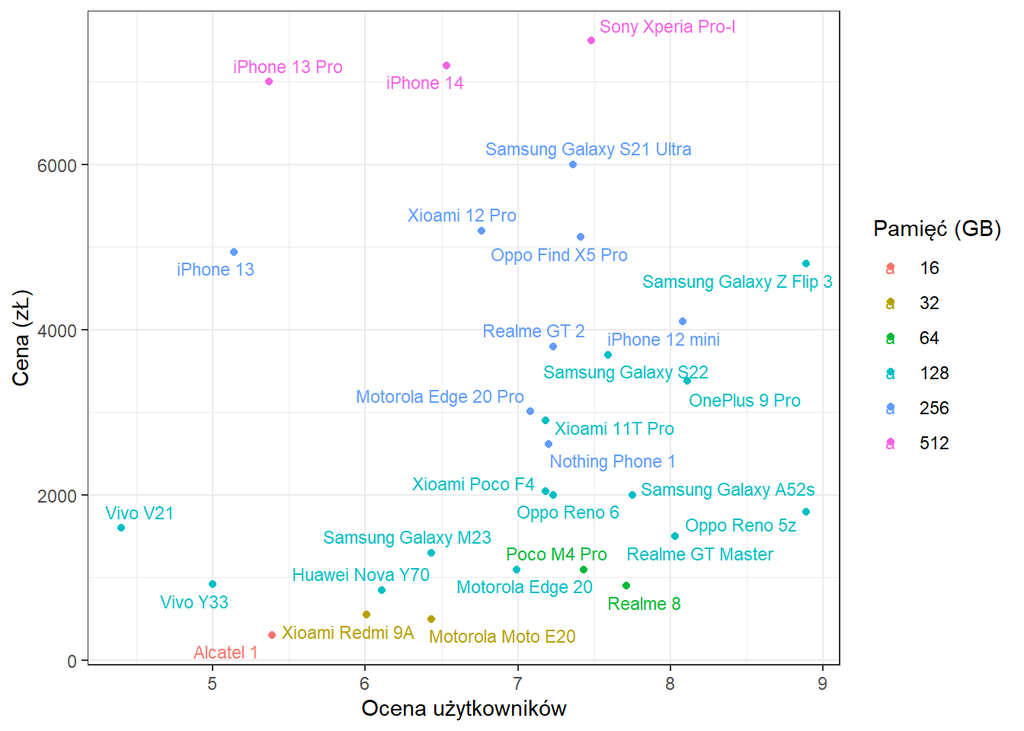

```r
library(ggplot2)
library(ggrepel)

ggplot(dane, aes(x = dane$Ocena, y = dane$Cena, color = factor(dane$Pamiec))) +
  geom_point()+
  guides(col = guide_legend("Pamięć (GB)")) +
  geom_text_repel(label = row.names(dane), size = 3) +
  xlab("Ocena użytkowników") +
  ylab("Cena (zŁ)") +
  theme_bw()
```

Rozkłady pamięci wbudowanej oraz pamięci RAM w badanym zbiorze telefonów

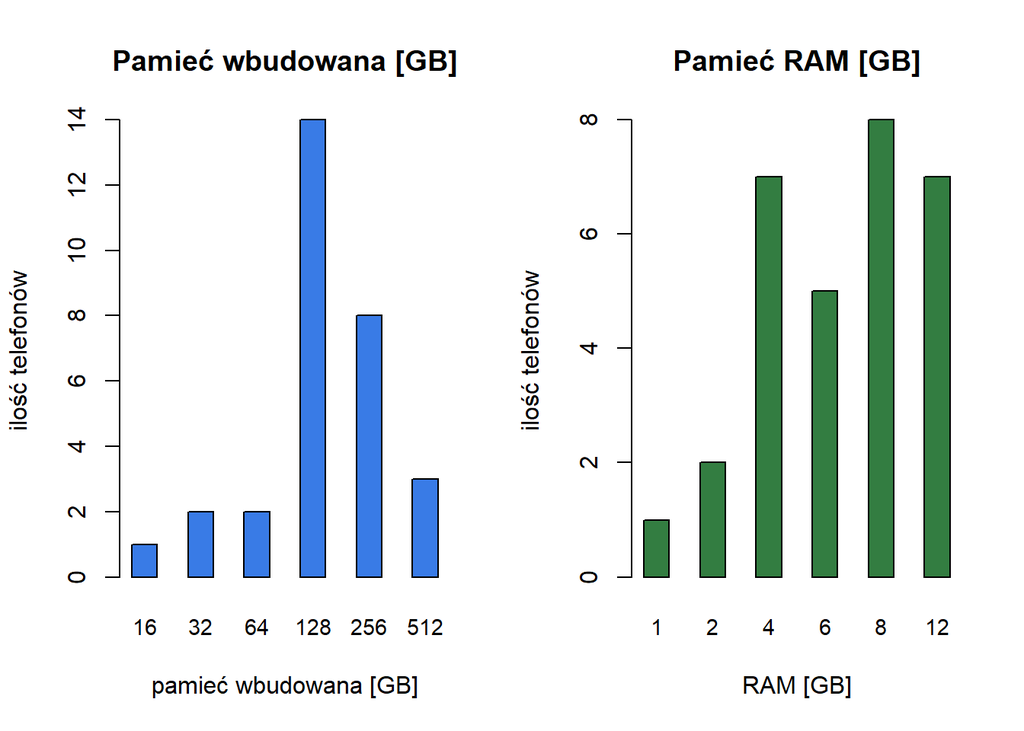

```r
par(mfrow = c(1,2))

barplot(table(dane[,4]),
        main = "Pamieć wbudowana [GB]",
        xlab = "pamieć wbudowana [GB]",
        ylab = "ilość telefonów",
        col = "#397be6",
        space = 1.2,
        cex.names = 0.9)


barplot(table(dane[,7]),
        main = "Pamieć RAM [GB]",
        xlab = "RAM [GB]",
        ylab = "ilość telefonów",
        space = 1.2,
        cex.names = 0.9,
        col = "#337d41")
```

Wykresy pudełkowe zmiennych

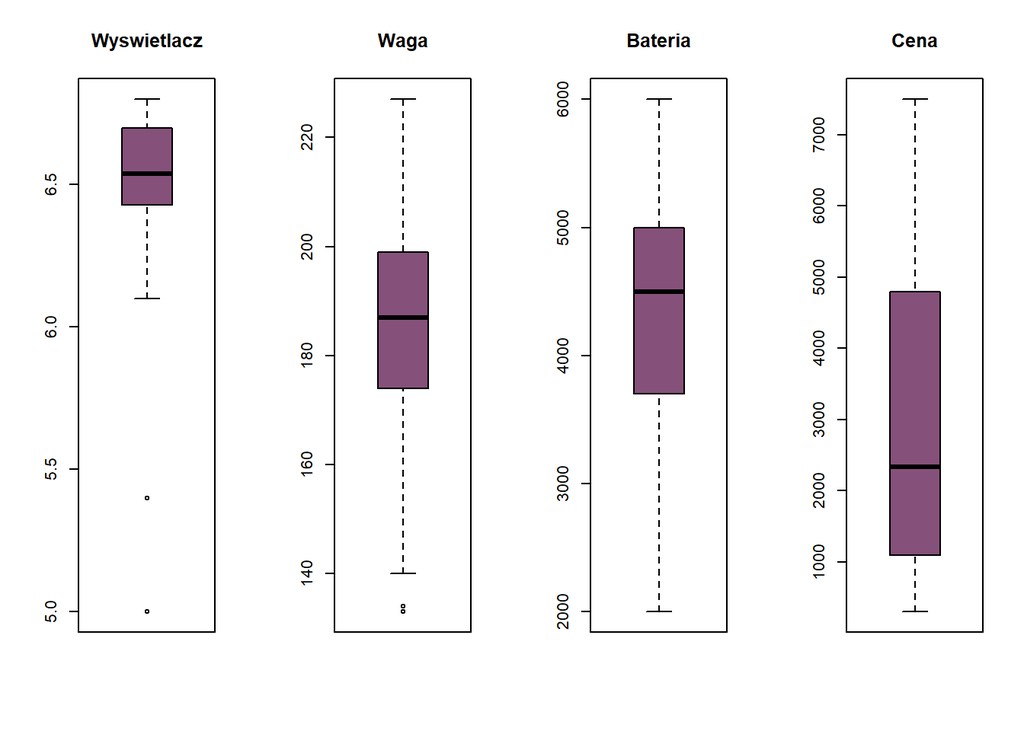

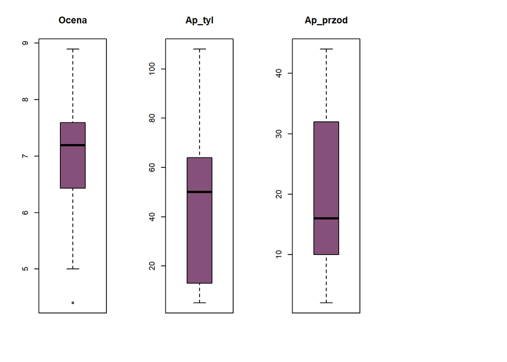

```r
par(mfrow = c(1,4))

zmienne <- c("Wyswietlacz", "Waga", "Bateria", "Cena", "Ocena", "Ap_tyl", "Ap_przod")

for (i in 1:7){
  z = zmienne[i]
  boxplot(dane[z], main = zmienne[i], col="#85517a")
}
```

Wykresy pudełkowe pozwalają na odczytanie wartości odstających poszczególnych zmiennych, jak widać zmienne Wyświetlacz, Waga oraz Ocena posiadają wartości odstające.

Wykres korelacji między zmiennymi

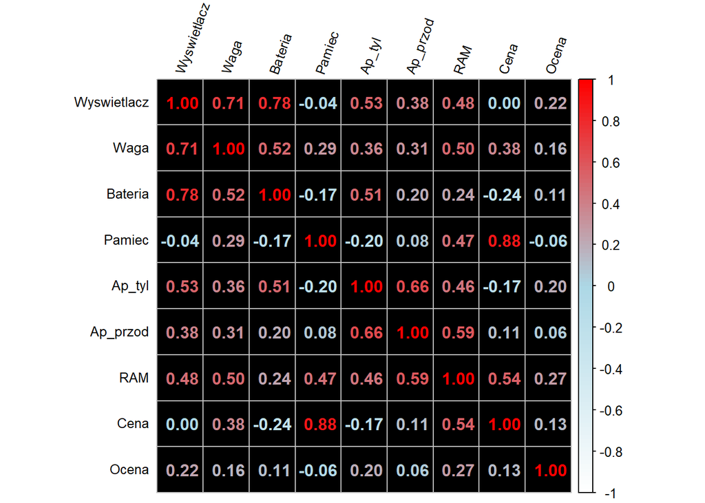

```r
library(corrplot)
corrplot(cor(dane), method = 'number', bg = "373737", col=colorRampPalette(c("white","lightblue","red"))(100), tl.col = "black", tl.cex = 0.8, tl.srt = 70)
```

Zmienne Wyświetlacz, Waga oraz Bateria bardzo silnie wpływają na siebie, innymi zmiennymi wyróżniającymi się wysokim współczynnikiem korelacji są Cena oraz Pamięć dla których korelacja wynosi 0.88. Ocena użytkowników jest jedyną zmienną dla której największa wartość korelacji wynosi 0.27 co pokazuje, że zmienna ta nie jest skorelowanna z żadną inną.

### **3) Porządkowanie liniowe**

Wykorzystując porządkowanie liniowe jesteśmy w stanie uporządkować obiekty wielowymiarowe od najgorszego do najlepszego ze względu na zmienną syntetyczną, która zależy od wartości cech charakteryzujących obiekty.

**Określenie zmiennych w badanym zbiorze**

Stymulanty są to zmienne, w których pożadane są jak najwyższe wartości, w badanym zbiorze stymulantami są: Bateria, Pamieć, Ap_tyl, Ap_przod, RAM oraz Ocena. Destymulantami powinny być: Waga oraz Cena, ponieważ przy coraz większych pojemnościach bateri oraz rozmiarów telefonów chcemy aby nasz smartfon był jak najlżejszy oraz kosztował jak najmniej. Jedyną nominantą jest zmienna Wyświetlacz, gdzie wartością optymalną jest 6,10”.

Zamiana nominanty na stymulantę

```r
wys_N = 6.10

for (i in 1:nrow(dane)){
  if(dane[i, "Wyswietlacz"] == wys_N){
    dane[i, "Wyswietlacz"] = 1
  } else if(dane[i, "Wyswietlacz"] < wys_N){
    dane[i, "Wyswietlacz"] = - 1 / (dane[i, "Wyswietlacz"] -  wys_N - 1)
  } else {
    dane[i, "Wyswietlacz"] = 1 / (dane[i, "Wyswietlacz"]  - wys_N + 1)
  }
}
```

Zamiana destymulanty na stymulante

```r
dane$Waga <- -1 * dane$Waga
dane$Cena <- -1 * dane$Cena
```

Standaryzacja zmiennych

```r
dane_st <- as.data.frame(scale(dane))
```

Dane po standaryzacji:

```r
kable(dane_st)
```

|  | Wyswietlacz | Waga | Bateria | Pamiec | Ap_tyl | Ap_przod | RAM | Cena | Ocena |
| --- | --- | --- | --- | --- | --- | --- | --- | --- | --- |
| Samsung Galaxy S22 | 2.210 | 0.766 | -0.689 | -0.438 | 0.107 | -0.750 | 0.284 | -0.330 | 0.586 |
| iPhone 13 | 2.210 | 0.498 | -1.150 | 0.526 | -1.203 | -0.574 | -0.890 | -0.908 | -1.644 |
| Xioami 12 Pro | -0.719 | -0.885 | 0.350 | 0.526 | 0.107 | 1.183 | 1.457 | -1.030 | -0.170 |
| Oppo Find X5 Pro | -0.631 | -1.465 | 0.812 | 0.526 | 0.107 | 1.183 | 1.457 | -0.992 | 0.422 |
| iPhone 14 | 2.210 | 0.587 | -1.150 | 2.454 | -1.203 | -0.574 | -0.303 | -1.962 | -0.379 |
| Xioami 11T Pro | -0.541 | -0.840 | 0.812 | -0.438 | 2.106 | -0.223 | 0.284 | 0.043 | 0.213 |
| iPhone 12 mini | -0.910 | 2.327 | -1.497 | 0.526 | -1.203 | -0.574 | -0.890 | -0.517 | 1.031 |
| Oppo Reno 6 | 0.330 | 0.141 | -1.497 | -0.438 | 0.589 | 1.183 | 0.284 | 0.462 | 0.258 |
| Samsung Galaxy S21 Ultra | -0.910 | -1.866 | 0.812 | 0.526 | 2.106 | 1.886 | 1.457 | -1.403 | 0.376 |
| Nothing Phone 1 | -0.141 | -0.394 | 0.235 | 0.526 | 0.107 | -0.223 | 1.457 | 0.173 | 0.231 |
| OnePlus 9 Pro | -0.631 | -0.528 | 0.235 | -0.438 | 0.107 | -0.574 | 0.284 | -0.181 | 1.059 |
| Vivo V21 | 0.288 | 0.409 | -0.342 | -0.438 | 0.589 | 2.237 | 0.284 | 0.649 | -2.317 |
| Realme GT 2 | -0.631 | -0.617 | 0.812 | 0.526 | 0.107 | 1.183 | 1.457 | -0.377 | 0.258 |
| Xioami Poco F4 | -0.541 | -0.840 | 0.235 | -0.438 | 0.589 | 0.129 | -0.303 | 0.439 | 0.213 |
| Motorola Edge 20 Pro | -0.631 | -0.216 | 0.235 | 0.526 | 2.106 | 1.183 | 1.457 | -0.010 | 0.122 |
| Realme GT Master | 0.330 | 0.498 | 0.004 | -0.438 | 0.589 | 1.183 | -0.303 | 0.695 | 0.986 |
| Samsung Galaxy A52s | 0.045 | -0.171 | 0.235 | -0.438 | 0.589 | 1.183 | -0.303 | 0.462 | 0.731 |
| Samsung Galaxy Z Flip 3 | -0.631 | 0.097 | -1.150 | -0.438 | -1.203 | -0.750 | 0.284 | -0.843 | 1.768 |
| Oppo Reno 5z | 0.330 | 0.543 | 0.004 | -0.438 | 0.038 | -0.223 | 0.284 | 0.555 | 1.768 |
| Poco M4 Pro | -0.316 | 0.230 | 0.812 | -0.920 | 0.107 | -0.223 | -0.890 | 0.882 | 0.440 |
| Samsung Galaxy M23 | -0.316 | -0.573 | 0.812 | -0.438 | 0.107 | -0.925 | -0.890 | 0.789 | -0.470 |
| Motorola Edge 20 | -0.316 | 0.721 | 0.812 | -0.438 | 0.107 | -0.223 | -0.890 | 0.882 | 0.040 |
| Huawei Nova Y70 | -0.775 | -0.617 | 1.966 | -0.438 | 0.038 | -0.925 | -0.890 | 0.998 | -0.761 |
| Realme 8 | 0.462 | 0.364 | 0.812 | -0.920 | 0.589 | -0.223 | -0.890 | 0.975 | 0.695 |
| Vivo Y33 | -0.247 | 2.015 | 0.812 | -0.438 | 0.107 | -0.223 | 0.284 | 0.966 | -1.771 |
| Xioami Redmi 9A | -0.068 | -0.483 | 0.812 | -1.161 | -1.168 | -1.189 | -1.477 | 1.138 | -0.852 |
| Alcatel 1 | -1.759 | 2.283 | -2.651 | -1.281 | -1.444 | -1.452 | -1.770 | 1.254 | -1.416 |
| Motorola Moto E20 | 0.045 | 0.007 | -0.342 | -1.161 | -1.168 | -1.189 | -1.477 | 1.162 | -0.470 |
| Sony Xperia Pro-I | 0.045 | -1.152 | 0.235 | 2.454 | -1.203 | -0.925 | 1.457 | -2.102 | 0.486 |
| iPhone 13 Pro | 2.210 | -0.840 | -1.381 | 2.454 | -1.203 | -0.574 | -0.303 | -1.869 | -1.434 |

#### **Metoda Hellwiga**

Metoda Hellwiga jest to metoda, w której punktem odniesienia obiektów w przestrzeni wielowymiarowej jest wzorzec, metoda ta również zakłada równe znaczenie wszystkich zmiennych opisujących obiekt. Metoda ta tworzy tzw. ranking, z którego łatwo odczytać, które obiekty są lepsze przy wcześniej ustalonym kryterium.

Wyznaczenie wzorca

```r
wzorzec <- c(max(dane_st$Wyswietlacz),
             max(dane_st$Waga),
             max(dane_st$Bateria),
             max(dane_st$Pamiec),
             max(dane_st$Ap_tyl),
             max(dane_st$Ap_przod),
             max(dane_st$RAM),
             max(dane_st$Cena),
             max(dane_st$Ocena))
wzorzec
```

```
## [1] 2.21 2.33 1.97 2.45 2.11 2.24 1.46 1.25 1.77
```

Obliczenie odległości od wzorca

```r
odl <- dane_st

for(i in 1:nrow(dane_st)){
  odl[i,] <- (dane_st[i,] - wzorzec) ^ 2
}

odl$odlSuma <- rowSums(odl)
odl$odlSuma <- sqrt(odl$odlSuma)
kable(odl)
```

|  | Wyswietlacz | Waga | Bateria | Pamiec | Ap_tyl | Ap_przod | RAM | Cena | Ocena | odlSuma |
| --- | --- | --- | --- | --- | --- | --- | --- | --- | --- | --- |
| Samsung Galaxy S22 | 0.00 | 2.438 | 7.05 | 8.37 | 4.00 | 8.922 | 1.38 | 2.511 | 1.399 | 6.00 |
| iPhone 13 | 0.00 | 3.345 | 9.71 | 3.72 | 10.95 | 7.903 | 5.51 | 4.677 | 11.641 | 7.58 |
| Xioami 12 Pro | 8.58 | 10.317 | 2.61 | 3.72 | 4.00 | 1.111 | 0.00 | 5.218 | 3.756 | 6.27 |
| Oppo Find X5 Pro | 8.07 | 14.378 | 1.33 | 3.72 | 4.00 | 1.111 | 0.00 | 5.047 | 1.813 | 6.28 |
| iPhone 14 | 0.00 | 3.027 | 9.71 | 0.00 | 10.95 | 7.903 | 3.10 | 10.345 | 4.611 | 7.05 |
| Xioami 11T Pro | 7.57 | 10.032 | 1.33 | 8.37 | 0.00 | 6.051 | 1.38 | 1.468 | 2.421 | 6.21 |
| iPhone 12 mini | 9.74 | 0.000 | 11.99 | 3.72 | 10.95 | 7.903 | 5.51 | 3.137 | 0.543 | 7.31 |
| Oppo Reno 6 | 3.54 | 4.778 | 11.99 | 8.37 | 2.30 | 1.111 | 1.38 | 0.628 | 2.281 | 6.03 |
| Samsung Galaxy S21 Ultra | 9.74 | 17.584 | 1.33 | 3.72 | 0.00 | 0.123 | 0.00 | 7.059 | 1.938 | 6.44 |
| Nothing Phone 1 | 5.53 | 7.405 | 3.00 | 3.72 | 4.00 | 6.051 | 0.00 | 1.169 | 2.364 | 5.76 |
| OnePlus 9 Pro | 8.07 | 8.151 | 3.00 | 8.37 | 4.00 | 7.903 | 1.38 | 2.060 | 0.504 | 6.59 |
| Vivo V21 | 3.70 | 3.680 | 5.33 | 8.37 | 2.30 | 0.000 | 1.38 | 0.367 | 16.689 | 6.46 |
| Realme GT 2 | 8.07 | 8.669 | 1.33 | 3.72 | 4.00 | 1.111 | 0.00 | 2.661 | 2.281 | 5.64 |
| Xioami Poco F4 | 7.57 | 10.032 | 3.00 | 8.37 | 2.30 | 4.446 | 3.10 | 0.665 | 2.421 | 6.47 |
| Motorola Edge 20 Pro | 8.07 | 6.466 | 3.00 | 3.72 | 0.00 | 1.111 | 0.00 | 1.597 | 2.712 | 5.16 |
| Realme GT Master | 3.54 | 3.345 | 3.85 | 8.37 | 2.30 | 1.111 | 3.10 | 0.312 | 0.612 | 5.15 |
| Samsung Galaxy A52s | 4.69 | 6.241 | 3.00 | 8.37 | 2.30 | 1.111 | 3.10 | 0.627 | 1.076 | 5.52 |
| Samsung Galaxy Z Flip 3 | 8.07 | 4.975 | 9.71 | 8.37 | 10.95 | 8.922 | 1.38 | 4.399 | 0.000 | 7.54 |
| Oppo Reno 5z | 3.54 | 3.184 | 3.85 | 8.37 | 4.28 | 6.051 | 1.38 | 0.489 | 0.000 | 5.58 |
| Poco M4 Pro | 6.38 | 4.396 | 1.33 | 11.38 | 4.00 | 6.051 | 5.51 | 0.139 | 1.765 | 6.40 |
| Samsung Galaxy M23 | 6.38 | 8.408 | 1.33 | 8.37 | 4.00 | 10.002 | 5.51 | 0.217 | 5.010 | 7.02 |
| Motorola Edge 20 | 6.38 | 2.579 | 1.33 | 8.37 | 4.00 | 6.051 | 5.51 | 0.139 | 2.988 | 6.11 |
| Huawei Nova Y70 | 8.91 | 8.669 | 0.00 | 8.37 | 4.28 | 10.002 | 5.51 | 0.066 | 6.398 | 7.22 |
| Realme 8 | 3.06 | 3.853 | 1.33 | 11.38 | 2.30 | 6.051 | 5.51 | 0.078 | 1.153 | 5.89 |
| Vivo Y33 | 6.04 | 0.098 | 1.33 | 8.37 | 4.00 | 6.051 | 1.38 | 0.083 | 12.527 | 6.31 |
| Xioami Redmi 9A | 5.19 | 7.899 | 1.33 | 13.07 | 10.72 | 11.739 | 8.61 | 0.013 | 6.866 | 8.09 |
| Alcatel 1 | 15.76 | 0.002 | 21.31 | 13.96 | 12.60 | 13.614 | 10.41 | 0.000 | 10.141 | 9.89 |
| Motorola Moto E20 | 4.69 | 5.381 | 5.33 | 13.07 | 10.72 | 11.739 | 8.61 | 0.009 | 5.010 | 8.03 |
| Sony Xperia Pro-I | 4.69 | 12.108 | 3.00 | 0.00 | 10.95 | 10.002 | 0.00 | 11.264 | 1.646 | 7.33 |
| iPhone 13 Pro | 0.00 | 10.032 | 11.20 | 0.00 | 10.95 | 7.903 | 3.10 | 9.756 | 10.257 | 7.95 |

Wyznaczenie odległości możliwe dalekiej od wzorca

```r
d0 <- mean(odl$odlSuma) + 2 * sd(odl$odlSuma)
d0
```

```
## [1] 8.69
```

Wyznaczenie miary Hellwiga

```r
HELLWIG <- data.frame(telefon = rownames(dane_st), miara = 1 - odl$odlSuma / d0)
```

Wyniki

```r
rownames(HELLWIG) <- NULL
kable(HELLWIG[order(HELLWIG$miara, decreasing = TRUE), ], row.names = FALSE)
```

| telefon | miara |
| --- | --- |
| Realme GT Master | 0.407 |
| Motorola Edge 20 Pro | 0.406 |
| Samsung Galaxy A52s | 0.365 |
| Oppo Reno 5z | 0.358 |
| Realme GT 2 | 0.351 |
| Nothing Phone 1 | 0.337 |
| Realme 8 | 0.322 |
| Samsung Galaxy S22 | 0.309 |
| Oppo Reno 6 | 0.306 |
| Motorola Edge 20 | 0.297 |
| Xioami 11T Pro | 0.285 |
| Xioami 12 Pro | 0.279 |
| Oppo Find X5 Pro | 0.277 |
| Vivo Y33 | 0.274 |
| Poco M4 Pro | 0.264 |
| Samsung Galaxy S21 Ultra | 0.259 |
| Vivo V21 | 0.256 |
| Xioami Poco F4 | 0.255 |
| OnePlus 9 Pro | 0.242 |
| Samsung Galaxy M23 | 0.193 |
| iPhone 14 | 0.189 |
| Huawei Nova Y70 | 0.169 |
| iPhone 12 mini | 0.159 |
| Sony Xperia Pro-I | 0.157 |
| Samsung Galaxy Z Flip 3 | 0.133 |
| iPhone 13 | 0.128 |
| iPhone 13 Pro | 0.085 |
| Motorola Moto E20 | 0.076 |
| Xioami Redmi 9A | 0.069 |
| Alcatel 1 | -0.138 |

Metoda Hellwiga pozwoliła na stworzenie rankingu, w którym najlepszymi telefonami okazały się Realme GT Master, Motorola Edge 20 Pro oraz Samsung Galaxy A52s. Telefony te charakteryzują się dobrymi parametrami, które powinny być wystarczające dla przeciętnego użytkownika, co więcej wymienione wcześniej smartfony cieszą się bardzo dobrą opinią wśród ich posiadaczy. Najgorzej w rankingu wypadły: Alcatel 1, Xioami Redmi 9A oraz Motorola Moto E20, nie ma tutaj żadnego zaskoczenia, ponieważ są to jedne z najtańszych oraz najsłabszych pod wględem parametrów telefony w badanym zbiorze. Lekkim zaskoczeniem wydaję się być niska pozycja smartfonów: Samsung Galaxy Z Flip 3 oraz Sony Xperia Pro-I. Smartfony posiadają bardzo dobre parametry oraz wysoką ocenę wśród użytkowników. Powodem tak słabych miejsc jest ustalone wcześniej kryterium, gdzie dla Samsunga są to bardzo słabe wartości rozdzielczości tylnego jak i przedniego apartu, a dla Sony Xperi jest to bardzo wygórowana cena, która wynosi 7499 zł.

#### **METODA STANDARYZOWANYCH SUM**

Metoda bezwzorcowa polegająca na sumowaniu zestandaryzowanych wartości dla każdego obiektu, a następnie konstruuje się względny wskaźnik poziomu rozwoju. Podobnie jak dla metody Hellwiga stworzony zostanie ranking, porównujący ze sobą dane smartfony.

Wyznaczenie parametrów

```r
ilosc_zm <- ncol(dane)
suma <- data.frame(rowSums(dane_st) / ilosc_zm)
colnames(suma) <- c("s")

suma_min <- min(suma)
for (i in 1:nrow(dane_st)){
  suma[i, 2] <- suma[i, 1] - suma_min
}
colnames(suma) <- c("s", "s-min(s)")
```

Standaryzacja danych

```r
suma_min <- min(suma[,1])

suma_max <- max(suma[,2])

for (i in 1:nrow(suma)){
  suma[i,1] <- (suma[i,1] - suma_min) / suma_max
}
```

Ranking

```r
STANDARYZOWANE_SUMY <- suma[order(suma$s, decreasing = TRUE), ]
STANDARYZOWANE_SUMY$`s-min(s)` <- NULL
kable(STANDARYZOWANE_SUMY)
```

|  | s |
| --- | --- |
| Motorola Edge 20 Pro | 1.000 |
| Realme GT Master | 0.906 |
| Samsung Galaxy S21 Ultra | 0.863 |
| Oppo Reno 5z | 0.853 |
| Realme GT 2 | 0.842 |
| Samsung Galaxy A52s | 0.813 |
| Nothing Phone 1 | 0.785 |
| Realme 8 | 0.777 |
| Samsung Galaxy S22 | 0.767 |
| Vivo Y33 | 0.749 |
| Oppo Find X5 Pro | 0.742 |
| Xioami 11T Pro | 0.742 |
| Vivo V21 | 0.738 |
| Oppo Reno 6 | 0.734 |
| Xioami 12 Pro | 0.696 |
| Motorola Edge 20 | 0.687 |
| Poco M4 Pro | 0.643 |
| iPhone 14 | 0.609 |
| Xioami Poco F4 | 0.593 |
| OnePlus 9 Pro | 0.582 |
| Sony Xperia Pro-I | 0.579 |
| Huawei Nova Y70 | 0.525 |
| iPhone 12 mini | 0.502 |
| Samsung Galaxy M23 | 0.487 |
| Samsung Galaxy Z Flip 3 | 0.413 |
| iPhone 13 Pro | 0.407 |
| iPhone 13 | 0.392 |
| Xioami Redmi 9A | 0.291 |
| Motorola Moto E20 | 0.280 |
| Alcatel 1 | 0.000 |

W stworzonym rankingu kolejny raz najgorszymi telefonami okazały się: Alcatel 1, Xioami Redmi 9A oraz Motorola Moto E20, jedyną różnicą jest zamiana kolejności między Xioami a Motorolą. W porównaniu do poprzedniego rankingu nastąpiła zmiana w czołóce, gdzie na miejsce Samsunga Galaxy A52s wskoczył Samsung Galaxy S21 Ultra, natomiast pozostałe dwa miejsca zajmują Realme GT Master oraz Motorola Edge 20 Pro. Ponownym zaskoczeniem jest niska pozycja Samsunga Galaxy Z Flip 3 oraz przeskok pozycji między dwoma rankingami telefonu Samsung Galaxy S21 Ultra, gdzie w pierwszym rankingu telefon znajdował się w połowie stawki, natomiast w drugim wskoczył na trzecie miejsce.

#### **Podsumowanie porządkowania liniowego**

Porządkowanie liniowe pozwoliło na porównanie oraz uporządkowanie telefonów, gdzie najlepszymi telefonami okazały się Realme GT Master oraz Motorola Edge 20 Pro, a zdecydowanie najgorszym Alcatel 1, który w obydwu rankingach zajął ostatnie miejsce.

### **4) Analiza skupień**

Inaczej zwana metodą uczenia maszynowego bez nadzoru dokonująca grupowania obiektów, w której podstawą grupowania jest podobieńtwo elementów wyrażone przy pomocy funkcji podobieństwa. Podczas grupowania chcemy aby nasze grupy były możliwie odmienne oraz elementy przypisane do tej samej grupy były do siebie możliwie podobne.

```r
dane <- read.csv2("telefony.csv", sep = ";", header = TRUE)
row.names(dane) <- dane$Telefon
dane$Telefon <- NULL
dane$Wyswietlacz <- as.numeric(dane$Wyswietlacz)
dane$Ocena <- as.numeric(dane$Ocena)

kable(dane)
```

|  | Wyswietlacz | Waga | Bateria | Pamiec | Ap_tyl | Ap_przod | RAM | Cena | Ocena |
| --- | --- | --- | --- | --- | --- | --- | --- | --- | --- |
| Samsung Galaxy S22 | 6.10 | 168 | 3700 | 128 | 50 | 10 | 8 | 3699 | 7.59 |
| iPhone 13 | 6.10 | 174 | 3300 | 256 | 12 | 12 | 4 | 4939 | 5.14 |
| Xioami 12 Pro | 6.73 | 205 | 4600 | 256 | 50 | 32 | 12 | 5200 | 6.76 |
| Oppo Find X5 Pro | 6.70 | 218 | 5000 | 256 | 50 | 32 | 12 | 5119 | 7.41 |
| iPhone 14 | 6.10 | 172 | 3300 | 512 | 12 | 12 | 6 | 7199 | 6.53 |
| Xioami 11T Pro | 6.67 | 204 | 5000 | 128 | 108 | 16 | 8 | 2899 | 7.18 |
| iPhone 12 mini | 5.40 | 133 | 3000 | 256 | 12 | 12 | 4 | 4099 | 8.08 |
| Oppo Reno 6 | 6.43 | 182 | 3000 | 128 | 64 | 32 | 8 | 2000 | 7.23 |
| Samsung Galaxy S21 Ultra | 6.80 | 227 | 5000 | 256 | 108 | 40 | 12 | 5999 | 7.36 |
| Nothing Phone 1 | 6.55 | 194 | 4500 | 256 | 50 | 16 | 12 | 2619 | 7.20 |
| OnePlus 9 Pro | 6.70 | 197 | 4500 | 128 | 50 | 12 | 8 | 3379 | 8.11 |
| Vivo V21 | 6.44 | 176 | 4000 | 128 | 64 | 44 | 8 | 1599 | 4.40 |
| Realme GT 2 | 6.70 | 199 | 5000 | 256 | 50 | 32 | 12 | 3799 | 7.23 |
| Xioami Poco F4 | 6.67 | 204 | 4500 | 128 | 64 | 20 | 6 | 2049 | 7.18 |
| Motorola Edge 20 Pro | 6.70 | 190 | 4500 | 256 | 108 | 32 | 12 | 3011 | 7.08 |
| Realme GT Master | 6.43 | 174 | 4300 | 128 | 64 | 32 | 6 | 1499 | 8.03 |
| Samsung Galaxy A52s | 6.50 | 189 | 4500 | 128 | 64 | 32 | 6 | 1999 | 7.75 |
| Samsung Galaxy Z Flip 3 | 6.70 | 183 | 3300 | 128 | 12 | 10 | 8 | 4799 | 8.89 |
| Oppo Reno 5z | 6.43 | 173 | 4300 | 128 | 48 | 16 | 8 | 1800 | 8.89 |
| Poco M4 Pro | 6.60 | 180 | 5000 | 64 | 50 | 16 | 4 | 1099 | 7.43 |
| Samsung Galaxy M23 | 6.60 | 198 | 5000 | 128 | 50 | 8 | 4 | 1299 | 6.43 |
| Motorola Edge 20 | 6.60 | 169 | 5000 | 128 | 50 | 16 | 4 | 1099 | 6.99 |
| Huawei Nova Y70 | 6.75 | 199 | 6000 | 128 | 48 | 8 | 4 | 849 | 6.11 |
| Realme 8 | 6.40 | 177 | 5000 | 64 | 64 | 16 | 4 | 899 | 7.71 |
| Vivo Y33 | 6.58 | 140 | 5000 | 128 | 50 | 16 | 8 | 919 | 5.00 |
| Xioami Redmi 9A | 6.53 | 196 | 5000 | 32 | 13 | 5 | 2 | 549 | 6.01 |
| Alcatel 1 | 5.00 | 134 | 2000 | 16 | 5 | 2 | 1 | 300 | 5.39 |
| Motorola Moto E20 | 6.50 | 185 | 4000 | 32 | 13 | 5 | 2 | 499 | 6.43 |
| Sony Xperia Pro-I | 6.50 | 211 | 4500 | 512 | 12 | 8 | 12 | 7499 | 7.48 |
| iPhone 13 Pro | 6.10 | 204 | 3100 | 512 | 12 | 12 | 6 | 7000 | 5.37 |

Przed przystąpieniem do analizy należy sprawdzić współczynnik zmienności oraz współliniowość zmiennych.

**Współczynniki korelacji między zmiennymi**

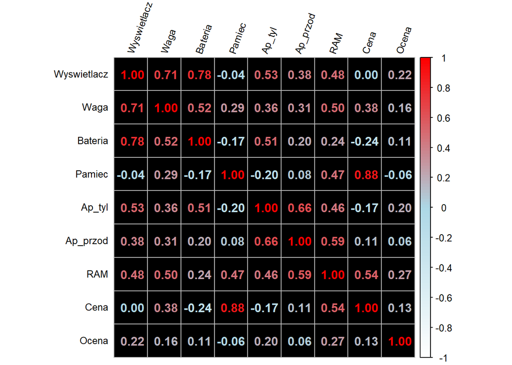

```r
library(corrplot)
corrplot(cor(dane), method = 'number', bg = "373737", col=colorRampPalette(c("white","lightblue","red"))(100), tl.col = "black", tl.cex = 0.8, tl.srt = 70)
```

Wartość współczynnika korelacji nie powinna być większa niż moduł z 0,9. Najwyższa korelacja występuje między zmiennymi Pamiec oraz Cena, lecz nie przekracza ona wcześniej założonego poziomu, podobnie jest z pozostałymi wartościami korelacji.

**Współczynnik zmienności**

```r
zmiennosc <- sapply(dane, function(x) sd(x, na.rm=T) / mean(x, na.rm=T) * 100)
zmiennosc
```

```
## Wyswietlacz        Waga     Bateria      Pamiec      Ap_tyl    Ap_przod
##        6.12       12.11       20.16       71.33       61.87       61.42
##         RAM        Cena       Ocena
##       48.47       71.73       15.82
```

Zmienne powinny posiadać współczynnik zmienności na poziomie powyżej 10%. W badanym zbiorze zmienność zmiennej Wyswietlacz wynosi 6,12% przez zmienna ta zostanie usunięta z modelu.

```r
dane$Wyswietlacz <- NULL
```

Nastepnie zostanie dokonana standaryzacja zmiennych

```r
dane_st <- as.data.frame(scale(dane))
kable(dane_st)
```

|  | Waga | Bateria | Pamiec | Ap_tyl | Ap_przod | RAM | Cena | Ocena |
| --- | --- | --- | --- | --- | --- | --- | --- | --- |
| Samsung Galaxy S22 | -0.766 | -0.689 | -0.438 | 0.107 | -0.750 | 0.284 | 0.330 | 0.586 |
| iPhone 13 | -0.498 | -1.150 | 0.526 | -1.203 | -0.574 | -0.890 | 0.908 | -1.644 |
| Xioami 12 Pro | 0.885 | 0.350 | 0.526 | 0.107 | 1.183 | 1.457 | 1.030 | -0.170 |
| Oppo Find X5 Pro | 1.465 | 0.812 | 0.526 | 0.107 | 1.183 | 1.457 | 0.992 | 0.422 |
| iPhone 14 | -0.587 | -1.150 | 2.454 | -1.203 | -0.574 | -0.303 | 1.962 | -0.379 |
| Xioami 11T Pro | 0.840 | 0.812 | -0.438 | 2.106 | -0.223 | 0.284 | -0.043 | 0.213 |
| iPhone 12 mini | -2.327 | -1.497 | 0.526 | -1.203 | -0.574 | -0.890 | 0.517 | 1.031 |
| Oppo Reno 6 | -0.141 | -1.497 | -0.438 | 0.589 | 1.183 | 0.284 | -0.462 | 0.258 |
| Samsung Galaxy S21 Ultra | 1.866 | 0.812 | 0.526 | 2.106 | 1.886 | 1.457 | 1.403 | 0.376 |
| Nothing Phone 1 | 0.394 | 0.235 | 0.526 | 0.107 | -0.223 | 1.457 | -0.173 | 0.231 |
| OnePlus 9 Pro | 0.528 | 0.235 | -0.438 | 0.107 | -0.574 | 0.284 | 0.181 | 1.059 |
| Vivo V21 | -0.409 | -0.342 | -0.438 | 0.589 | 2.237 | 0.284 | -0.649 | -2.317 |
| Realme GT 2 | 0.617 | 0.812 | 0.526 | 0.107 | 1.183 | 1.457 | 0.377 | 0.258 |
| Xioami Poco F4 | 0.840 | 0.235 | -0.438 | 0.589 | 0.129 | -0.303 | -0.439 | 0.213 |
| Motorola Edge 20 Pro | 0.216 | 0.235 | 0.526 | 2.106 | 1.183 | 1.457 | 0.010 | 0.122 |
| Realme GT Master | -0.498 | 0.004 | -0.438 | 0.589 | 1.183 | -0.303 | -0.695 | 0.986 |
| Samsung Galaxy A52s | 0.171 | 0.235 | -0.438 | 0.589 | 1.183 | -0.303 | -0.462 | 0.731 |
| Samsung Galaxy Z Flip 3 | -0.097 | -1.150 | -0.438 | -1.203 | -0.750 | 0.284 | 0.843 | 1.768 |
| Oppo Reno 5z | -0.543 | 0.004 | -0.438 | 0.038 | -0.223 | 0.284 | -0.555 | 1.768 |
| Poco M4 Pro | -0.230 | 0.812 | -0.920 | 0.107 | -0.223 | -0.890 | -0.882 | 0.440 |
| Samsung Galaxy M23 | 0.573 | 0.812 | -0.438 | 0.107 | -0.925 | -0.890 | -0.789 | -0.470 |
| Motorola Edge 20 | -0.721 | 0.812 | -0.438 | 0.107 | -0.223 | -0.890 | -0.882 | 0.040 |
| Huawei Nova Y70 | 0.617 | 1.966 | -0.438 | 0.038 | -0.925 | -0.890 | -0.998 | -0.761 |
| Realme 8 | -0.364 | 0.812 | -0.920 | 0.589 | -0.223 | -0.890 | -0.975 | 0.695 |
| Vivo Y33 | -2.015 | 0.812 | -0.438 | 0.107 | -0.223 | 0.284 | -0.966 | -1.771 |
| Xioami Redmi 9A | 0.483 | 0.812 | -1.161 | -1.168 | -1.189 | -1.477 | -1.138 | -0.852 |
| Alcatel 1 | -2.283 | -2.651 | -1.281 | -1.444 | -1.452 | -1.770 | -1.254 | -1.416 |
| Motorola Moto E20 | -0.007 | -0.342 | -1.161 | -1.168 | -1.189 | -1.477 | -1.162 | -0.470 |
| Sony Xperia Pro-I | 1.152 | 0.235 | 2.454 | -1.203 | -0.925 | 1.457 | 2.102 | 0.486 |
| iPhone 13 Pro | 0.840 | -1.381 | 2.454 | -1.203 | -0.574 | -0.303 | 1.869 | -1.434 |

Algorytmy analizy skupień są bardzo czułe na występowanie wartości odstających, dlatego za pomocą reguły trzech sigm zostaną zidentyfikowane wartości odstające. Reguła mówi, że jeśli choć jedna zmienna obiektu jest na moduł większa od 3 to ten obiekt jest outlierem.

```r
odstajace <- c()
for (row in 1:nrow(dane_st)){
  for (elem in 1:ncol(dane_st)){
    if (abs(dane_st[row, elem]) > 3){
      odstajace <- append(odstajace, row.names(dane[row, ]))
      break
    }
  }
}

odstajace
```

[output not shown]

Jak widać żaden z obiektów nie posiada wartości odstających, więc dane są gotowe do wykorzystania w analizie skupień.

### **Grupowanie podziałowe**

W tym rodzaju grupowania zostanie utworzonych k możliwie odmiennych skupień, gdzie definując metrykę **d** jako odległość między obiektami uzyskany zostaje warunek:
$$min\left\{\displaystyle\sum_{n=1}^{N} \frac{1}{\#G_n}
\displaystyle\sum_{P_i,P_j \in G_n} d\left(P_i, P_j \right) \right\}$$
dla którego podobieństwo wewnątrz grup jest jak największe, a skupienia są jak najbardziej różne od siebie. W tym grupowaniu zostanie użyta metoda k-średnich, lecz przed przeprowadzenniem badania należy ustalić liczbę k rozłącznych skupień. W tym celu posłużę się metodą łokcia oraz metodą profilu.

#### **Metoda k-średnich**

Na samym początku zostanie użyta metoda k-średnich dla 2 oraz 3 grup, gdzie parametr nstart zostanie ustawiony na 20

Podział na 2 grupy

```r
gr2 <- kmeans(x = dane_st, centers = 2, nstart = 20)
gr2$cluster
```

```
##        Samsung Galaxy S22                 iPhone 13             Xioami 12 Pro
##                         1                         1                         2
##          Oppo Find X5 Pro                iPhone 14             Xioami 11T Pro
##                         2                         2                         1
##            iPhone 12 mini              Oppo Reno 6  Samsung Galaxy S21 Ultra
##                         1                         1                         2
##           Nothing Phone 1             OnePlus 9 Pro                  Vivo V21
##                         2                         1                         1
##               Realme GT 2            Xioami Poco F4     Motorola Edge 20 Pro
##                         2                         1                         2
##          Realme GT Master      Samsung Galaxy A52s    Samsung Galaxy Z Flip 3
##                         1                         1                         1
##              Oppo Reno 5z              Poco M4 Pro         Samsung Galaxy M23
##                         1                         1                         1
##          Motorola Edge 20          Huawei Nova Y70                   Realme 8
##                         1                         1                         1
##                  Vivo Y33           Xioami Redmi 9A                Alcatel 1
##                         1                         1                         1
##         Motorola Moto E20         Sony Xperia Pro-I             iPhone 13 Pro
##                         1                         2                         2
```

Porównanie statystyk w grupach

```r
library(psych)
dane$gr2 <- as.factor(gr2$cluster)
describeBy(dane[,-8], group = dane$gr2)
```

```
##
##  Descriptive statistics by group
## group: 1
##          vars  n    mean      sd median trimmed     mad  min  max range  skew
## Waga        1 21  177.86   20.91    180  180.00   16.31  133  204    71 -0.85
## Bateria     2 21 4257.14  938.39   4500 4317.65  741.30 2000 6000  4000 -0.53
## Pamiec      3 21  119.62   59.36    128  114.82    0.00   16  256   240  0.52
## Ap_tyl      4 21   45.48   25.70     50   45.06   20.76    5  108   103  0.10
## Ap_przod    5 21   16.19   10.61     16   15.12    8.90    2   44    42  1.03
## RAM         6 21    5.48    2.36      6    5.65    2.97    1    8     7 -0.24
## Cena        7 21 2012.95 1414.11   1599 1866.76 1037.82  300 4939  4639  0.77
## gr2*        8 21    1.00    0.00      1    1.00    0.00    1    1     0   NaN
##          kurtosis     se
## Waga        -0.16   4.56
## Bateria     -0.29 204.77
## Pamiec       0.62  12.95
## Ap_tyl      -0.31   5.61
## Ap_przod     0.27   2.32
## RAM         -1.38   0.51
## Cena        -0.74 308.58
## gr2*          NaN   0.00
## ------------------------------------------------------------
## group: 2
##          vars n   mean      sd median trimmed    mad  min  max range  skew
## Waga        1 9  202.2   16.17    204   202.2   14.8  172  227    55 -0.27
## Bateria     2 9 4388.9  711.41   4500  4388.9  741.3 3100 5000  1900 -0.84
## Pamiec      3 9  341.3  128.00    256   341.3    0.0  256  512   256  0.59
## Ap_tyl      4 9   50.2   37.18     50    50.2   56.3   12  108    96  0.47
## Ap_przod    5 9   24.0   11.83     32    24.0   11.9    8   40    32 -0.13
## RAM         6 9   10.7    2.65     12    10.7    0.0    6   12     6 -1.12
## Cena        7 9 5271.7 1821.27   5200  5271.7 2668.7 2619 7499  4880 -0.18
## gr2*        8 9    2.0    0.00      2     2.0    0.0    2    2     0   NaN
##          kurtosis     se
## Waga        -0.88   5.39
## Bateria     -1.01 237.14
## Pamiec      -1.81  42.67
## Ap_tyl      -1.33  12.39
## Ap_przod    -1.91   3.94
## RAM         -0.80   0.88
## Cena        -1.71 607.09
## gr2*          NaN   0.00
```

Wizualizacja

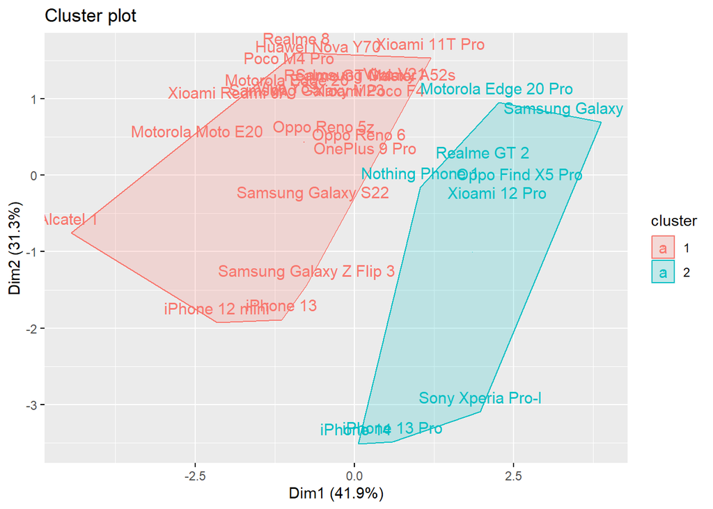

```r
library(factoextra)
fviz_cluster(gr2, dane[,1:7], geom = "text")
```

Podział na 3 grupy

```r
gr3 <- kmeans(x = dane_st, centers=3, nstart=20)
gr3$cluster
```

```
##        Samsung Galaxy S22                 iPhone 13             Xioami 12 Pro
##                         3                         2                         3
##          Oppo Find X5 Pro                iPhone 14             Xioami 11T Pro
##                         3                         2                         3
##            iPhone 12 mini              Oppo Reno 6  Samsung Galaxy S21 Ultra
##                         2                         3                         3
##           Nothing Phone 1             OnePlus 9 Pro                  Vivo V21
##                         3                         3                         3
##               Realme GT 2            Xioami Poco F4     Motorola Edge 20 Pro
##                         3                         3                         3
##          Realme GT Master      Samsung Galaxy A52s    Samsung Galaxy Z Flip 3
##                         3                         3                         2
##              Oppo Reno 5z              Poco M4 Pro         Samsung Galaxy M23
##                         3                         1                         1
##          Motorola Edge 20          Huawei Nova Y70                   Realme 8
##                         1                         1                         1
##                  Vivo Y33           Xioami Redmi 9A                Alcatel 1
##                         1                         1                         1
##         Motorola Moto E20         Sony Xperia Pro-I             iPhone 13 Pro
##                         1                         2                         2
```

Porównanie statystyk w grupach

```r
dane$gr3 <- as.factor(gr3$cluster)
describeBy(dane[,-5], group = dane$gr3)
```

```
##
##  Descriptive statistics by group
## group: 1
##         vars n    mean      sd  median trimmed    mad  min     max   range
## Waga       1 9  175.33   24.02  180.00  175.33  23.72  134  199.00   65.00
## Bateria    2 9 4666.67 1118.03 5000.00 4666.67   0.00 2000 6000.00 4000.00
## Pamiec     3 9   80.00   48.00   64.00   80.00  71.16   16  128.00  112.00
## Ap_tyl     4 9   38.11   21.48   50.00   38.11   2.97    5   64.00   59.00
## RAM        5 9    3.67    2.00    4.00    3.67   0.00    1    8.00    7.00
## Cena       6 9  834.67  325.38  899.00  834.67 296.52  300 1299.00  999.00
## Ocena      7 9    6.39    0.89    6.43    6.39   0.83    5    7.71    2.71
## gr2*       8 9    1.00    0.00    1.00    1.00   0.00    1    1.00    0.00
## gr3*       9 9    1.00    0.00    1.00    1.00   0.00    1    1.00    0.00
##          skew kurtosis     se
## Waga    -0.64    -1.25   8.01
## Bateria -1.33     0.84 372.68
## Pamiec  -0.05    -1.98  16.00
## Ap_tyl  -0.48    -1.68   7.16
## RAM      0.74    -0.09   0.67
## Cena    -0.25    -1.44 108.46
## Ocena   -0.02    -1.39   0.30
## gr2*      NaN      NaN   0.00
## gr3*      NaN      NaN   0.00
## ------------------------------------------------------------
## group: 2
##         vars n    mean      sd  median trimmed     mad     min     max   range
## Waga       1 6  179.50   27.76  178.50  179.50   23.72  133.00  211.00   78.00
## Bateria    2 6 3416.67  545.59 3300.00 3416.67  148.26 3000.00 4500.00 1500.00
## Pamiec     3 6  362.67  170.13  384.00  362.67  189.77  128.00  512.00  384.00
## Ap_tyl     4 6   12.00    0.00   12.00   12.00    0.00   12.00   12.00    0.00
## RAM        5 6    6.67    3.01    6.00    6.67    2.97    4.00   12.00    8.00
## Cena       6 6 5922.50 1471.77 5969.50 5922.50 1779.12 4099.00 7499.00 3400.00
## Ocena      7 6    6.92    1.50    7.01    6.92    2.01    5.14    8.89    3.75
## gr2*       8 6    1.50    0.55    1.50    1.50    0.74    1.00    2.00    1.00
## gr3*       9 6    2.00    0.00    2.00    2.00    0.00    2.00    2.00    0.00
##          skew kurtosis     se
## Waga    -0.43    -1.31  11.33
## Bateria  1.19    -0.33 222.74
## Pamiec  -0.18    -2.05  69.46
## Ap_tyl    NaN      NaN   0.00
```

[output cut: 12 more lines]

```
## RAM        5 15    9.20    2.48    8.00    9.23    2.97    6.0   12.00    6.00
## Cena       6 15 3111.33 1417.41 2899.00 3013.23 1334.34 1499.0 5999.00 4500.00
## Ocena      7 15    7.29    0.96    7.23    7.39    0.27    4.4    8.89    4.49
## gr2*       8 15    1.40    0.51    1.00    1.38    0.00    1.0    2.00    1.00
## gr3*       9 15    3.00    0.00    3.00    3.00    0.00    3.0    3.00    0.00
##          skew kurtosis     se
## Waga     0.25    -0.97   4.39
## Bateria -1.08     0.71 140.57
## Pamiec   0.37    -1.98  16.76
## Ap_tyl   1.09    -0.53   5.84
## RAM      0.10    -1.78   0.64
## Cena     0.65    -0.94 365.97
## Ocena   -1.46     3.16   0.25
## gr2*     0.37    -1.98   0.13
## gr3*      NaN      NaN   0.00
```

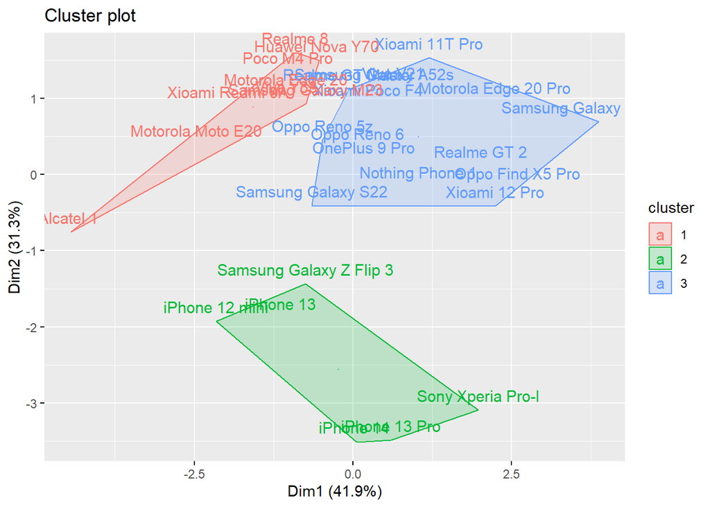

```r
fviz_cluster(gr3, dane[,1:7], geom = "text")
```

Podział na 3 grupy wydaję się być nieco lepszym w porównaniu do dwóch grup. Grupy są bardziej zróżnicowane oraz elementy w grupach nieco bardziej jednorodne. Nasuwa się jednak pytanie czy podział na 3 skupienia jest wystarczająco dobry? Metoda łokcia oraz profilu pozwoli na sprawdzenie tej tezy.

#### **Metoda lokcia**

Metoda ta polega na znalezieniu grup, w których łaczna suma wariancji jest jak najmniejsza. Im mniejsza wariancja w grupie tym obiekty będą bardziej zbliżone do siebie.

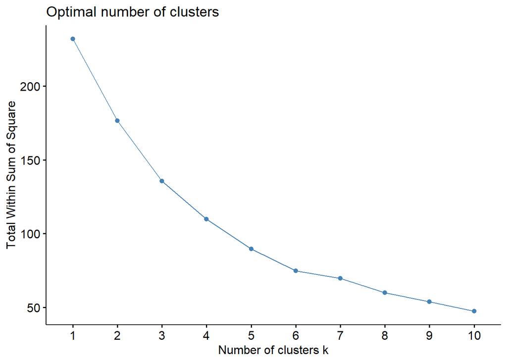

```r
fviz_nbclust(dane_st, kmeans, method = "wss")
```

Jak widać na powyższym wykresie suma wariacji maleje wraz ze wzrostem podziału na większą liczbę klastrów. Optymalną liczbę klastrów znajduję się w miejscu, gdzie wykres przestaję gwałtownie maleć lub widać tak zwany “łokieć”. W tym przypadku metoda łokcia wskazuje na wybór co najmniej 3 klastróW. Aby dokonać ostatecznego wybory przeprowadzona zostanie metoda profilu.

#### **Metoda profilu**

W tej metodzie obliczany jest wskaźnik sylwetkowy dla każdego obiektu, gdzie uwzględniany jest dystans między obiektami w grupie oraz dystans pomiędzy grupami. Na podstawnie obliczonego współczynnika, można określić czy obiekt został przypisany do odpowiedniej grupy.

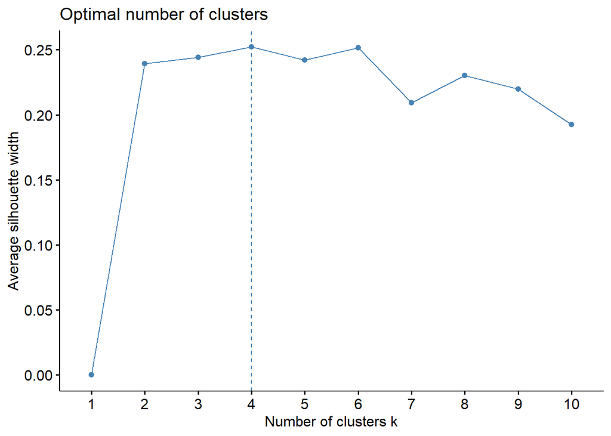

```r
fviz_nbclust(dane_st, kmeans, method = "silhouette")
```

Metoda wskazuje na wybór 4 klastrów.

k = 4

```r
gr4 <- kmeans(x = dane_st, centers = 4, nstart = 20)
gr4$cluster
```

```
##        Samsung Galaxy S22                 iPhone 13             Xioami 12 Pro
##                         4                         4                         3
##          Oppo Find X5 Pro                iPhone 14             Xioami 11T Pro
##                         3                         1                         3
##            iPhone 12 mini              Oppo Reno 6  Samsung Galaxy S21 Ultra
##                         4                         3                         3
##           Nothing Phone 1             OnePlus 9 Pro                  Vivo V21
##                         3                         3                         3
##               Realme GT 2            Xioami Poco F4     Motorola Edge 20 Pro
##                         3                         3                         3
##          Realme GT Master      Samsung Galaxy A52s    Samsung Galaxy Z Flip 3
##                         3                         3                         4
##              Oppo Reno 5z              Poco M4 Pro         Samsung Galaxy M23
##                         3                         2                         2
##          Motorola Edge 20          Huawei Nova Y70                   Realme 8
##                         2                         2                         2
##                  Vivo Y33           Xioami Redmi 9A                Alcatel 1
##                         2                         2                         4
##         Motorola Moto E20         Sony Xperia Pro-I             iPhone 13 Pro
##                         2                         1                         1
```

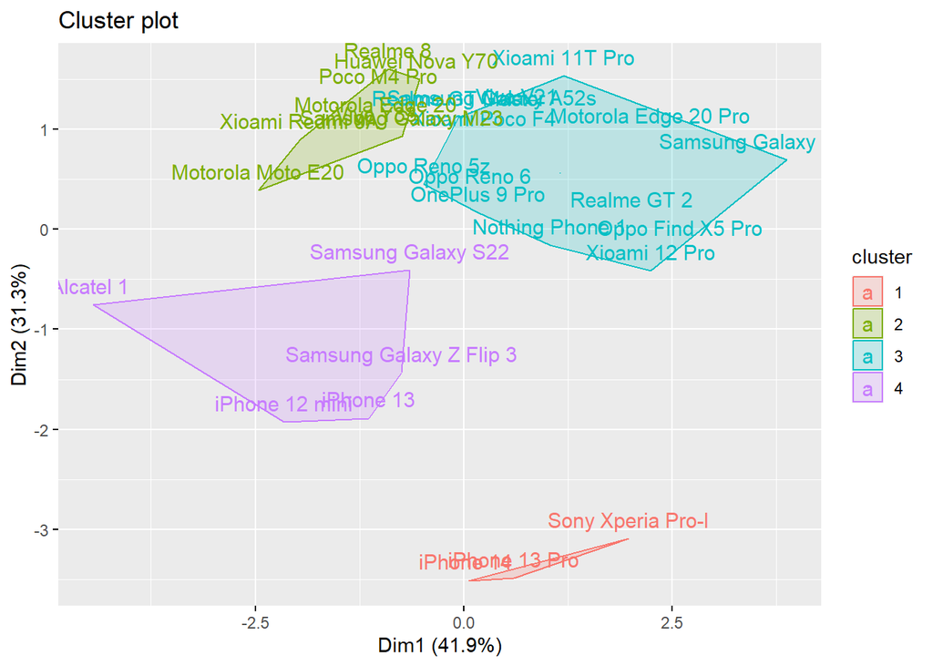

```r
fviz_cluster(gr4, dane[,1:7], geom = "text")
```

Po przenalizowaniu metodu łokcia oraz profilu zdecydowałem się na wybór 4 klastrów. Wybór wydaję się dość sensowny, lecz przed przeprowadzeniem ostatecznej analizy zostanie wykonana jeszcze jedna metoda z grupowania hierarchicznego.

#### **Grupowanie hierarchiczne**

Poprzez wykorzystanie funkcji odległości, każdy obiekt ze zbioru jest łączony w coraz to większe grupy, aż do uzyskannia jednego skupienia zawierającego wszystkie obiekty.

#### **Metoda Warda**

Jest najczęściej wykorzystywaną metodą w grupowaniu hierarchicznym, bazuje ona na analizie wariancji (ANOVA). W każdym etapie minimalizuje ona wzrost łacznej sumy kwadratów odchyleń wszystkich cech dla każdego obiektu w obrębie grupy od średnuch w skupieniu.

Wyznacznie odległosci średnich oraz grupowanie z wykorzystaniem metody Warda

```r
dist_euclidean <- dist(dane_st, method="euclidean")
ward_euclidean <- hclust(dist_euclidean, method="ward.D2")
```

Wizualicja wyników

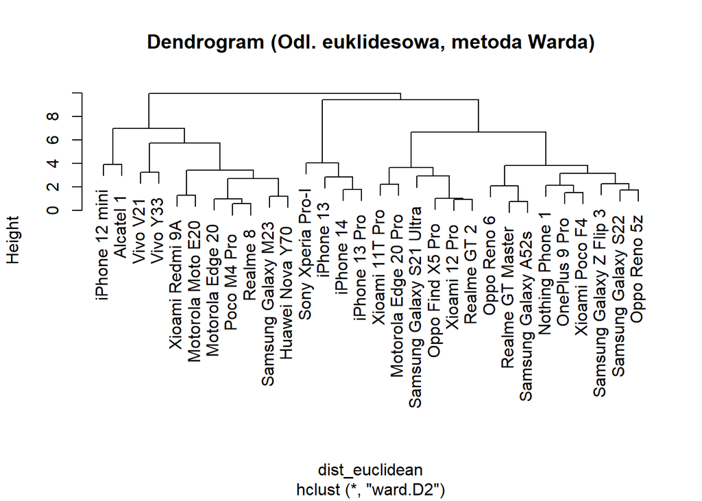

```r
plot(ward_euclidean, main="Dendrogram (Odl. euklidesowa, metoda Warda)")
```

Analiza wykresu wiązania względem etapów wiązania

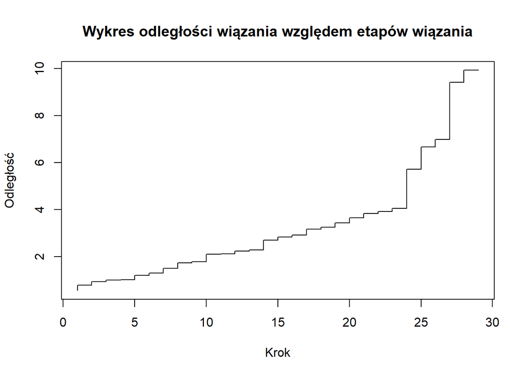

```r
plot(x=1:29, y= ward_euclidean$height, type="S",
     xlab="Krok", ylab="Odległość",
     main = "Wykres odległości wiązania względem etapów wiązania")
```

Na powyższym wykresie można łatwo zauważyć, że największe zróżnicowanie wartości występuje między 4 a 6 oraz 7 a 9 odległością. Dlatego wybór ilości grup z wcześniej wymienionych przedziałów będzie jak najbardziej poprawny.

Analiza indeksów ocen jakości klasyfikacji

```r
library(clusterSim)
index <- data.frame(k=0, G1=0, G2=0, G3=0, S=0)
for(i in 2:10){
  cluster <- cutree(ward_euclidean, k=i)
  index[i-1, "k"]  <- i
  index[i-1, "G1"] <- index.G1(dane_st, cluster)
  index[i-1, "G2"] <- index.G2(dist_euclidean, cluster)
  index[i-1, "G3"] <- index.G3(dist_euclidean, cluster)
  index[i-1, "S"] <- index.S(dist_euclidean, cluster)
}
```

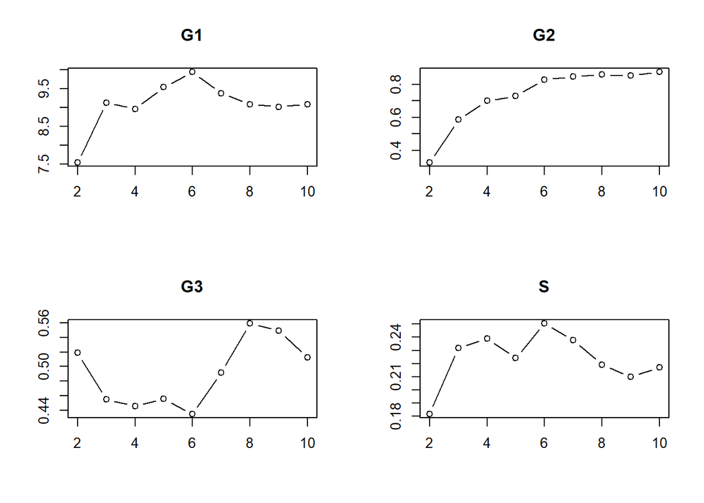

```r
par(mfrow=c(2,2))
plot(x=index$k, y=index$G1, main="G1", type="b", xlab="", ylab="")
plot(x=index$k, y=index$G2, main="G2", type="b", xlab="", ylab="")
plot(x=index$k, y=index$G3, main="G3", type="b", xlab="", ylab="")
plot(x=index$k, y=index$S, main="S", type="b", xlab="", ylab="")
```

Analizując indeksy oceny jakości klasyfikacji należy wybrać największe wartości G1, G2 oraz S, natomiast dla indeksu G3 najmniejszą wartość. Po przeanalizowaniu wykresu wiązania oraz indeksów jakości klasyfikacji można śmiało stwierdzić, że najlepszym wyborem będzie 6 grup.

Podział na 6 grup na podstawie dendogramu

```r
cutree(ward_euclidean, k=6)
```

```
##        Samsung Galaxy S22                 iPhone 13             Xioami 12 Pro
##                         1                         2                         3
##          Oppo Find X5 Pro                iPhone 14             Xioami 11T Pro
##                         3                         2                         3
##            iPhone 12 mini              Oppo Reno 6  Samsung Galaxy S21 Ultra
##                         4                         1                         3
##           Nothing Phone 1             OnePlus 9 Pro                  Vivo V21
##                         1                         1                         5
##               Realme GT 2            Xioami Poco F4     Motorola Edge 20 Pro
##                         3                         1                         3
##          Realme GT Master      Samsung Galaxy A52s    Samsung Galaxy Z Flip 3
##                         1                         1                         1
##              Oppo Reno 5z              Poco M4 Pro         Samsung Galaxy M23
##                         1                         6                         6
##          Motorola Edge 20          Huawei Nova Y70                   Realme 8
##                         6                         6                         6
##                  Vivo Y33           Xioami Redmi 9A                Alcatel 1
##                         5                         6                         4
##         Motorola Moto E20         Sony Xperia Pro-I             iPhone 13 Pro
##                         6                         2                         2
```

#### **Podsumowanie**

Metody grupowania podziałowego oraz hierarchicznego przyczyniły się do stworzenia grup oraz przydzielenia do nich odpowiednich obiektów. W metodzie k-średnich otrzymany został ostateczny podział na 4 grupy, natomiast metoda Warda wskazała podział na 6 grup. Wydaję się, że oba podziały są bardzo dobre, obiekty w stworzonych grupach powinny byc w miarę jednolitę a grupy powinny sie znacznie różnić od siebie.